# FML Assignment 1

Harika

2024-02-04

# QUESTION 1:

# Download a dataset from the web. You may use any source, but specify the source in your code. Also ensure that the data has a mix of quantitative and qualitative (categorical) variables.

# QUESTION 2:

# Import the dataset into R

```r
# Load the dataset
house_prices <- read.csv("C:/Users/its me/OneDrive - Kent State University/Desktop/Rhistory/House_Prices.csv")
```

```r
str(house_prices)
```

```
## 'data.frame':    900 obs. of  13 variables:
##  $ LotArea     : int  8450 9600 11250 9550 14260 14115 10084 10382 6120 7420 ...
##  $ OverallQual : int  7 6 7 7 8 5 8 7 7 5 ...
##  $ YearBuilt   : int  2003 1976 2001 1915 2000 1993 2004 1973 1931 1939 ...
##  $ YearRemodAdd: int  2003 1976 2002 1970 2000 1995 2005 1973 1950 1950 ...
##  $ BsmtFinSF1  : int  706 978 486 216 655 732 1369 859 0 851 ...
##  $ FullBath    : int  2 2 2 1 2 1 2 2 2 1 ...
##  $ HalfBath    : int  1 0 1 0 1 1 0 1 0 0 ...
##  $ BedroomAbvGr: int  3 3 3 3 4 1 3 3 2 2 ...
##  $ TotRmsAbvGrd: int  8 6 6 7 9 5 7 7 8 5 ...
##  $ Fireplaces  : int  0 1 1 1 1 0 1 2 2 2 ...
##  $ GarageArea  : int  548 460 608 642 836 480 636 484 468 205 ...
##  $ YrSold      : int  2008 2007 2008 2006 2008 2009 2007 2009 2008 2008 ...
##  $ SalePrice   : int  208500 181500 223500 140000 250000 143000 307000 200000 129900 118000 ...
```

# QUESTION 3:

# Print out descriptive statistics for a selection of quantitative and categorical variables.

```r
# Display the first few rows of the dataset
head(house_prices)
```

```
##   LotArea OverallQual YearBuilt YearRemodAdd BsmtFinSF1 FullBath HalfBath
## 1    8450           7      2003         2003        706        2        1
## 2    9600           6      1976         1976        978        2        0
## 3   11250           7      2001         2002        486        2        1
## 4    9550           7      1915         1970        216        1        0
## 5   14260           8      2000         2000        655        2        1
## 6   14115           5      1993         1995        732        1        1
##   BedroomAbvGr TotRmsAbvGrd Fireplaces GarageArea YrSold SalePrice
## 1            3            8          0        548   2008    208500
## 2            3            6          1        460   2007    181500
## 3            3            6          1        608   2008    223500
## 4            3            7          1        642   2006    140000
## 5            4            9          1        836   2008    250000
## 6            1            5          0        480   2009    143000
```

```r
# Descriptive statistics for quantitative variables
summary(house_prices$SalePrice)
```

```
##    Min. 1st Qu.  Median    Mean 3rd Qu.    Max.
##   34900  130000  163000  183108  216878  755000
```

```r
# Descriptive statistics for categorical variables
table(house_prices$ FullBath)
```

```
##
##   0   1   2   3
##   5 405 467  23
```

#Descriptive statistics for quantitative variable “SalePrice”: The quantitative variable “SalePrice” exhibits the following descriptive statistics:

- Minimum (Min.): $34,900, denoting the lowest sale price in the dataset.
- First Quartile (1st Qu.): $130,000, indicating that 25% of the sale prices fall below this value.
- Median: $163,000, representing the middle value when all sale prices are arranged in ascending order.
- Mean: Approximately $183,108, serving as the average sale price.
- Third Quartile (3rd Qu.): $216,878, signifying that 75% of the sale prices are below this threshold.
- Maximum (Max.): $755,000, the highest sale price observed in the dataset.

#Descriptive statistics for categorical variable “FullBath”: Here are the descriptive statistics for the categorical variable “FullBath”:

-Category 0: There are 5 instances where the number of full bathrooms is 0.

-Category 1: There are 405 instances where the number of full bathrooms is 1.

-Category 2: There are 467 instances where the number of full bathrooms is 2.

-Category 3: There are 23 instances where the number of full bathrooms is 3.

# QUESTION 4:

# Transform at least one variable. It doesn’t matter what the transformation is.

```r
# Transform a variable
house_prices$LogSalePrice <- log(house_prices$SalePrice)
```

# QUESTION 5:

# Plot at least one quantitative variable, and one scatterplot

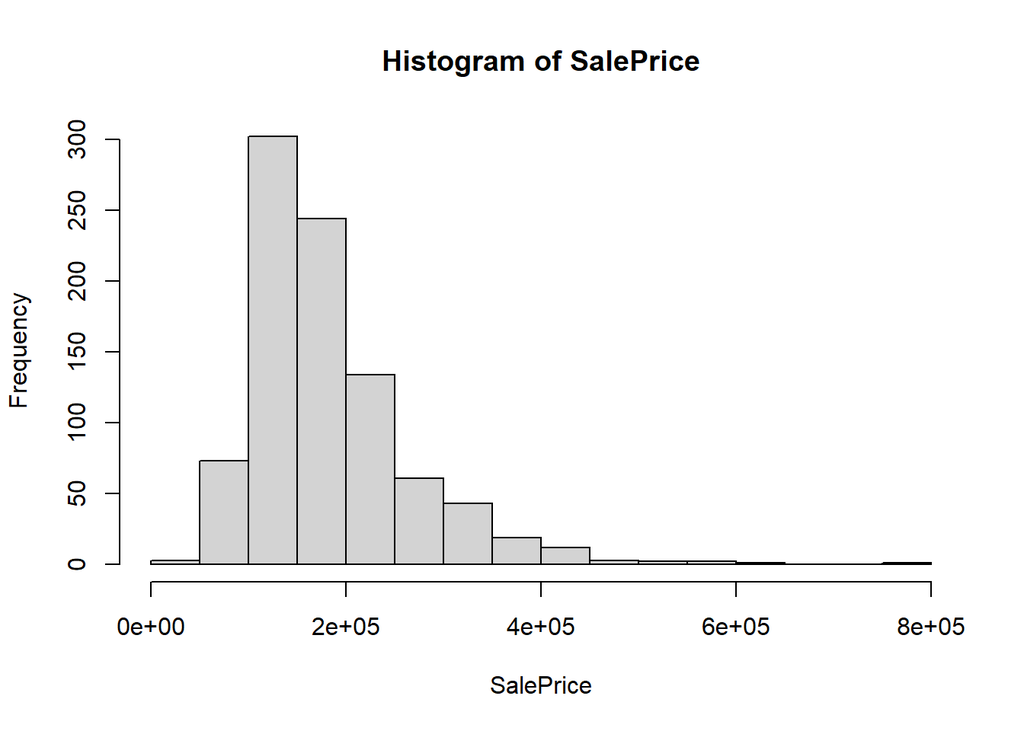

```r
# Plotting a quantitative variable
hist(house_prices$SalePrice, main = "Histogram of SalePrice", xlab = "SalePrice")
```

```r
# Check for missing values in GarageArea and SalePrice
sum(is.na(house_prices$GarageArea))
```

```
## [1] 0
```

```r
sum(is.na(house_prices$SalePrice))
```

```
## [1] 0
```

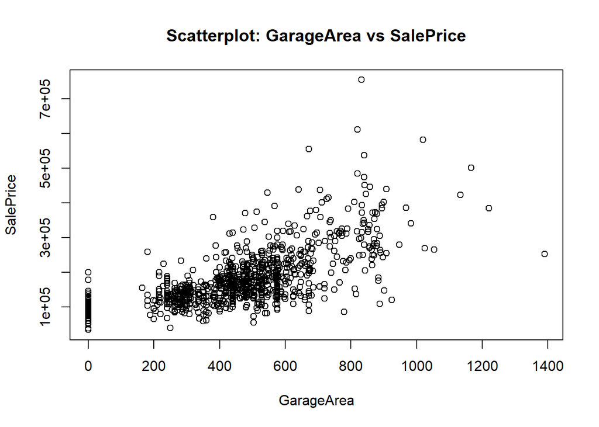

```r
# Remove rows with missing values
house_prices <- na.omit(house_prices)

# Plotting a scatterplot
plot(house_prices$GarageArea, house_prices$SalePrice,
     main = "Scatterplot: GarageArea vs SalePrice",
     xlab = "GarageArea", ylab = "SalePrice")
```